# Prova Parcial Novembre 2013

Laura Julià

7/11/2017

## PROBLEMA 1

```r
library(MASS)
y <- c(2.1, 1.9, 2, 2.2, 1.2, 0.8, 1.1, 0.9, 5.1, 5.2, 4.9, 4.9, 7.9, 8, 8.2,
    7.9)
x <- c(rep(c(1, 0, -1, 0), 4), rep(c(0, 1, 0, -1), 4), rep(c(1, 1, 0, 0), 4),
    rep(c(2, 2, -1, -1), 4))
x <- matrix(x, ncol = 4, byrow = T)
betas <- ginv(t(x) %*% x) %*% t(x) %*% y
```

#### S’ha realizat un experiment amb quatre situacions experimentals diferents i quatre rèpliques per a cadascuna.

#### Les dades són:

[output not shown]

#### Contesteu les següents qüestions:

#### (a) Quina condició ha de verificar una funció paramètrica per a que sigui estimable en aquest model?

En aquest model les f.p.e són les combinacions lineals $aα+bβ+cγ+dδ$ tals que

```
           a−b+c−d=0
```

#### (b) Indiqueu si les funcions paramètriques següents són estimables i calculeu l’estimador MQ quan sigui possible:

```
    (i)α
    (ii)α + β
    (iii)α + β + γ + δ
```

```r
library(MASS)
betas <-ginv(t(x)%*%x) %*% t(x) %*% y
betas
```

```
##          [,1]
## [1,] 2.765625
## [2,] 2.240625
## [3,] 0.734375
## [4,] 1.259375
```

```r
#i)
#No es estimable

#ii)
betas[1]+betas[2]
```

```
## [1] 5.00625
```

```r
#[1] 5.00625

#iii)
betas[1]+betas[2]+betas[3]+betas[4]
```

```
## [1] 7
```

```r
#[1] 7

# TAMBÉ:

# i)
#No es fpe.

# ii) alpha + beta
sum(betas[1:2])
```

```
## [1] 5.00625
```

```r
## [1] 5.006

# iii) alpha + beta + gamma + delta
sum(betas)
```

```
## [1] 7
```

```r
## [1] 7
```

#### (c) Calculeu l’estimació de les variàncies dels estimadors lineals òptims de les funcions paràmetriques estimables $α+β$ i $2α+β−γ$ i la covariància entre ells.

Primer calcularem l’estimació de la variància dels errors

```r
residus <- y - x %*% betas
RSS <- sum(residus^2)
sigma2 <- RSS/(16 - 3)
```

La variància estimada de l’estimació de $α+β$ és

```r
a <- c(1, 1, 0, 0)
as.numeric(sigma2 * t(a) %*% ginv(t(x) %*% x) %*% a)
```

```
## [1] 0.004083534
```

La variància estimada de l’estimació de $2α+β−γ$ és

```r
b <- c(2, 1, -1, 0)
as.numeric(sigma2 * t(b) %*% ginv(t(x) %*% x) %*% b)
```

```
## [1] 0.005444712
```

i la covariància

```r
as.numeric(sigma2 * t(a) %*% ginv(t(x) %*% x) %*% b)
```

```
## [1] 0.002722356
```

#### (d) Feu el contrast de les dues hipòtesis

```
    H0(1) :α+β=5i
    H0(2) :α+β=5,2α+β−γ=7.
```

Per fer el contrast de la hipòtesi $H(1)0:α+β=5$ considerem el estadístic t de Student:

```r
t.est <- as.numeric((sum(betas[1:2]) - 5)/sqrt(sigma2 * t(a) %*% ginv(t(x) %*%
    x) %*% a))
# p-valor
pt(t.est, 16 - 3, lower.tail = F) * 2
```

```
## [1] 0.9235789
```

De manera que acceptem la hipòtesi nul·la.

Per fer el contrast de la hipòtesi $H(2)0:α+β=5,2α+β−γ=7$ ho farem com un contrast de models. El model complet és l’anterior del que ja hem calculat la suma de quadrats residual. Ara hem de fer el mateix amb el model de la hipòtesi nul·la. En primer lloc observem que $α+β=5,2α+β−γ=7$ és equivalent a $β=5−α$ i $γ=α−2$, llavors tenim:

```
    α−γ=2
    β−δ=5−α−δ
    α+β=5
    2α+2β−γ−δ=12−α−δ
```

Si pasem les constants a la banda de les observacions tenim un nou vector d’observacions

```r
y0 <- y - c(rep(2, 4), rep(5, 4), rep(5, 4), rep(12, 4))
```

La nova matriu de disseny té, en principi, dos paràmetres $α$ i $δ$.

```r
x0 <- c(rep(c(0, 0), 4), rep(c(-1, -1), 4), rep(c(0, 0), 4), rep(c(-1, -1), 4))
matrix(x0, ncol = 2, byrow = T)
```

```
##       [,1] [,2]
##  [1,]    0    0
##  [2,]    0    0
##  [3,]    0    0
##  [4,]    0    0
##  [5,]   -1   -1
##  [6,]   -1   -1
##  [7,]   -1   -1
##  [8,]   -1   -1
##  [9,]    0    0
## [10,]    0    0
## [11,]    0    0
## [12,]    0    0
## [13,]   -1   -1
## [14,]   -1   -1
## [15,]   -1   -1
## [16,]   -1   -1
```

però és evident que el rang és 1 i en realitat els dos paràmetres són el mateix. Així doncs la matriu de disseny de la hipòtesi nul·la es pot simplificar

```r
x0 <- c(rep(0, 4), rep(-1, 4), rep(0, 4), rep(-1, 4))
```

Ara ja podem calcular la suma de quadrats residual de la hipòtesi nul·la i el test F

```r
beta0 <- solve(t(x0) %*% x0) %*% t(x0) %*% y0
residus0 <- y0 - x0 * beta0
RSS0 <- sum(residus0^2)
f.est <- ((RSS0 - RSS)/2)/(RSS/(16 - 3))
pf(f.est, 2, 16 - 3, lower.tail = F)
```

```
## [1] 0.8556013
```

Acceptem la hipòtesi nul·la.

## PROBLEMA 2

#### Anem a treballar amb la llista d’observacions de 934 nens i nenes en 205 famílies sobre la que Galton (1886) va basar la seva taula de freqüències i els principis de la regressió. Per estudiar la influència de l’altura dels pares en la dels fills, Galton va fer algunes discutibles simpli cacions. Per exemple, va fer servir com a variable regressora una “mitjana” de l’altura del pare i de la mare. A més, va multiplicar per 1.08 l’altura de les dones per ajustar els seus valors als dels homes. També va considerar tots els fills i filles de cada família.

#### En aquest problema estudiarem la relació entre l’altura dels pares (homes) i els lls (homes) si tu ets un home i la relació entre les mares i les lles si tu ets una dona.

#### Les següents instruccions seleccionen les dades:

```
        library(HistData)
        data(GaltonFamilies)
        help(GaltonFamilies)
        # escull el teu cas:
        # sexe <- "male"
        # sexe <- "female"
        GaltonFills <- GaltonFamilies[GaltonFamilies$gender==sexe, ]
        # selecció a l'atzar d'un únic fill o filla per familia
         rownames(GaltonFills) <- 1:dim(GaltonFills)[1]
          set.seed(123)
         ff <- function(x) sample(which(GaltonFills$family==x),1)
          ind <- sapply(unique(GaltonFills$family),ff)
        # data.frame per treballar
        GaltonFills1 <- GaltonFills[ind, ]
```

Seleccionem les dades:

```r
library(HistData)
data(GaltonFamilies)
help(GaltonFamilies)
# escull el teu cas:
# sexe <- "male"
# sexe <- "female"
GaltonFills <- GaltonFamilies[GaltonFamilies$gender=="female", ]
# selecció a l'atzar d'un ?nic fill o filla per familia
rownames(GaltonFills) <- 1:dim(GaltonFills)[1]
set.seed(123)
ff <- function(x) as.numeric(sample(as.character(which(GaltonFills$family==x)),1))
ind <- sapply(unique(GaltonFills$family),ff)
# data.frame per treballar
GaltonFills1 <- GaltonFills[ind, ]
```

#### (a) Feu un gràfic de dispersió de les variables. Feu una primera regressió lineal per identi car residus molt grans. L’anàlisi dels residus us pot ajudar.

#### Indiqueu dues observacions que poden ser atípiques però no les elimineu de la base de dades.

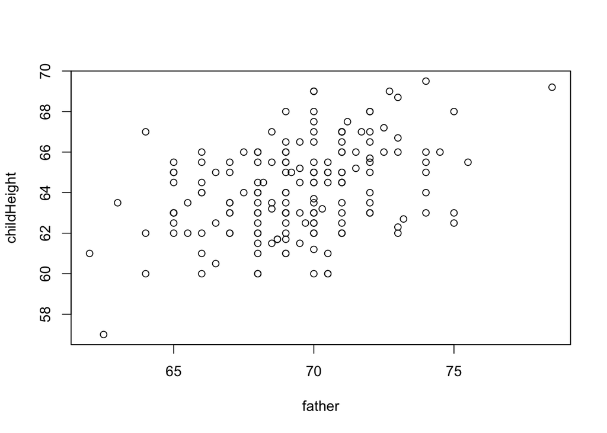

```r
with(GaltonFills1, plot(father, childHeight))
```

Fem també una primera regressió:

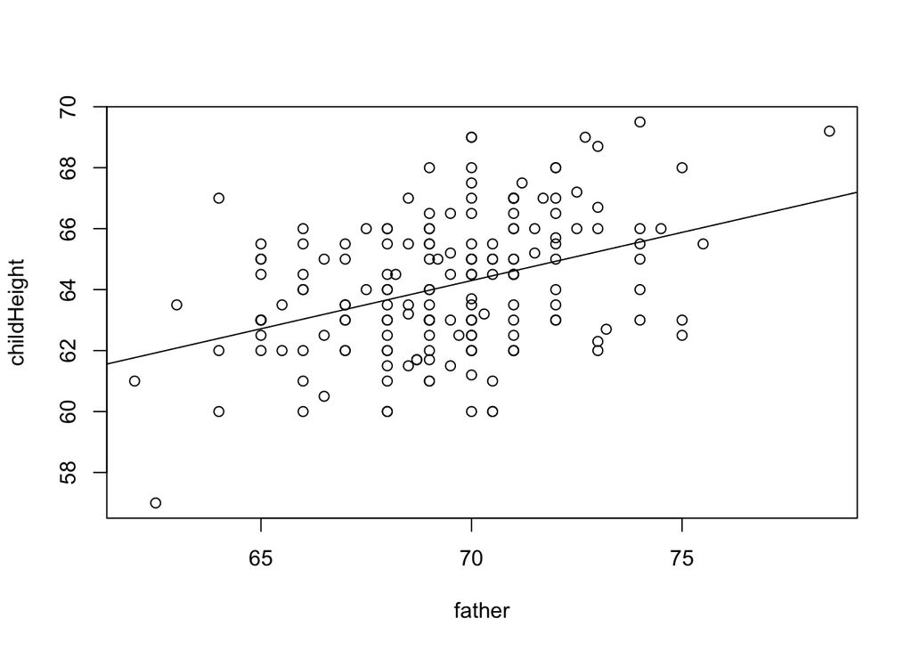

```r
g <- lm(childHeight ~ father, data = GaltonFills1)
with(GaltonFills1, plot(father, childHeight))
abline(g)
```

i considerem una anàlisi gràfica dels residus amb la instrucció

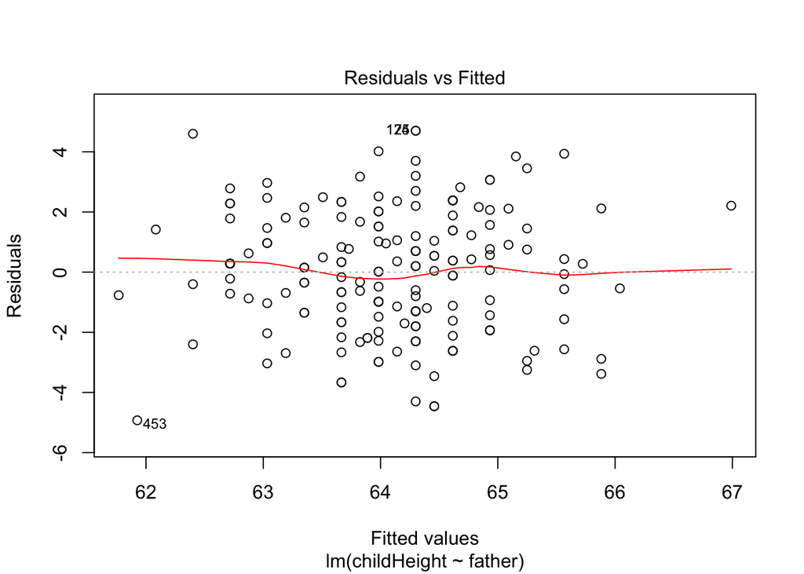

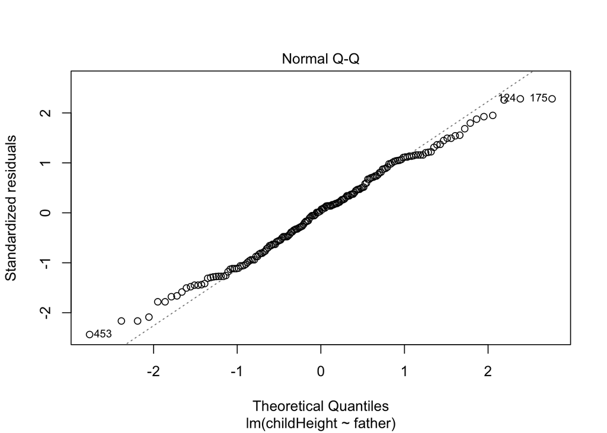

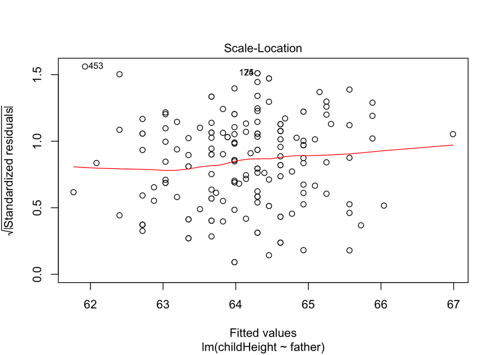

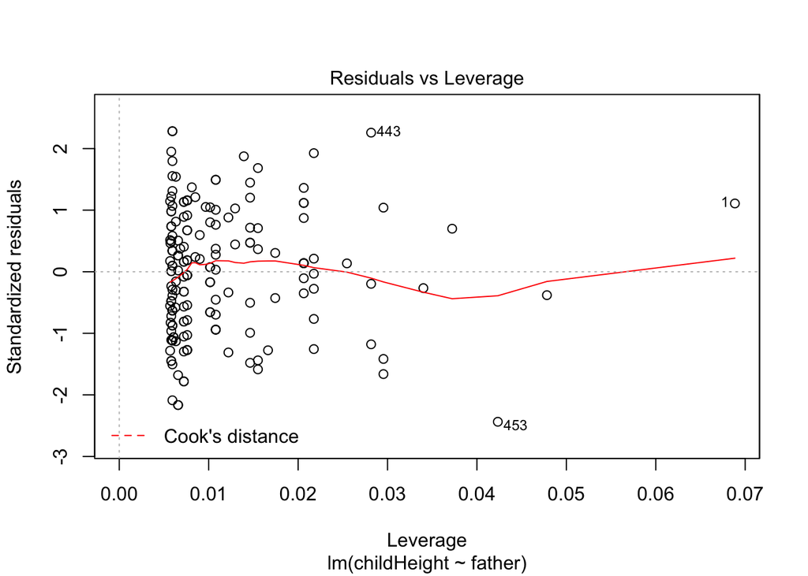

```r
plot(g)
```